# MA22015 2026 - Coursework

## Generative AI statement

```r
# GenAI Usage:
# 1) Identifying political stances of candidates, to group into left/center/right in Q4,
# 2) R code specifically for making ggplots,
# 3) Checking for spelling and grammatical inconsistencies.
```

## Setup

```r
library(ggplot2)
polpres <- read.csv("polpres.csv")
```

The wordcount: 1496

```r
library(rmdwc)
rmdcount("cw26.Rmd")$words
```

```
[1] 1496
```

## 1. Additional Voters

```r
candidates <- c("Bartoszewicz","Biejat","Braun","Hołownia","Jakubiak",
"Maciak","Mentzen","Nawrocki","Senyszyn","Stanowski",
"Trzaskowski","Woch","Zandberg")

polpres$round1 <- rowSums(polpres[, candidates])
polpres$round2 <- polpres$N2 + polpres$T2 + polpres$spoilt
polpres$additional <- polpres$round2 - polpres$round1

q1data <- polpres[polpres$province != "", ]
```

Zagranica (foreign countries) and statki (ships) have no province and are not Polish counties, so were excluded. Additional voters were calculated as the difference between round 2 total votes and round 1 total votes.

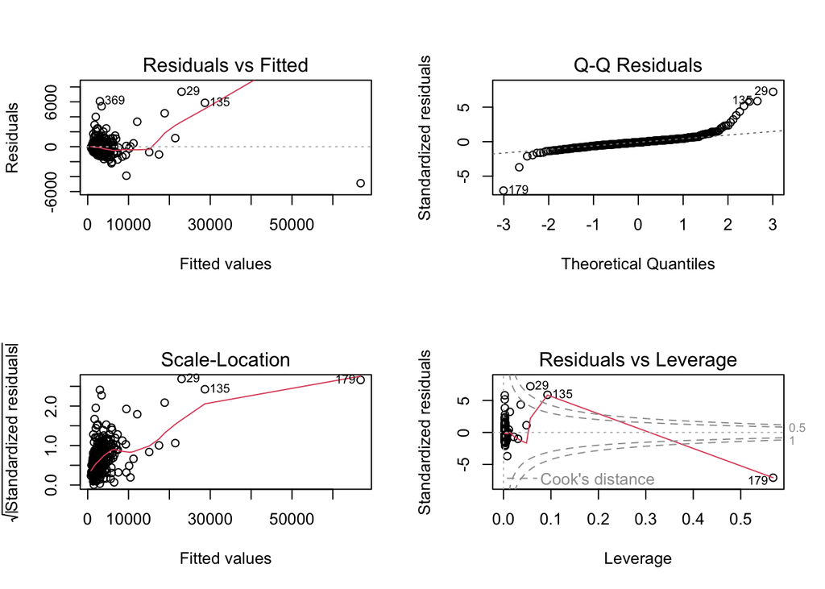

```r
lmod1_before <- lm(additional ~ round1, data = q1data)
par(mfrow = c(2, 2))
plot(lmod1_before)
```

```r
lmod1_after <- lm(log(additional) ~ log(round1), data = q1data)
summary(lmod1_after)
```

```
Call:
lm(formula = log(additional) ~ log(round1), data = q1data)

Residuals:
     Min       1Q   Median       3Q      Max
-0.63474 -0.16322 -0.00643  0.13788  1.13018

Coefficients:
            Estimate Std. Error t value Pr(>|t|)
(Intercept) -1.53615    0.22103   -6.95 1.61e-11 ***
log(round1)  0.89103    0.02092   42.60  < 2e-16 ***
---
Signif. codes:  0 '***' 0.001 '**' 0.01 '*' 0.05 '.' 0.1 ' ' 1

Residual standard error: 0.2606 on 378 degrees of freedom
Multiple R-squared:  0.8276,    Adjusted R-squared:  0.8272
F-statistic:  1815 on 1 and 378 DF,  p-value: < 2.2e-16
```

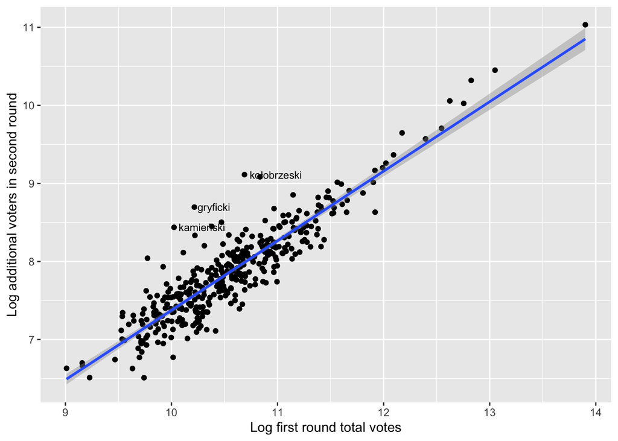

```r
stud <- rstudent(lmod1_after)
q1data$stud <- stud

n <- nrow(q1data)
threshold <- qt(0.05 / (2 * n), df = n - 2 - 1)
q1data$outlier <- abs(q1data$stud) > abs(threshold)

ggplot(q1data, aes(log(round1), log(additional))) + geom_point() +
geom_smooth(method = "lm") + geom_text(data = q1data[q1data$outlier, ],
aes(label = county), hjust = -0.1, size = 3) + xlab("Log first round total votes") + ylab("Log additional voters in second round")
```

Studentized residuals were tested against a Bonferroni-corrected threshold, which produced three outliers: Gryficki (4.45), Kołobrzeski (4.43), and Kamieński (4.09). All 3 of these counties are found in the Zachodniopomorskie province as well as being coastal towns, which may reflect holidaymakers voting there, though other explanations are possible.

## 2. Exit Poll

```r
p <- sum(polpres$T2) / (sum(polpres$T2) + sum(polpres$N2))
```

Spoilt votes were excluded as these are unlikely to represent voters who truthfully revealed their choice, and we cannot make any conclusions yet about where these votes would have ended up.

Modelling the survey as 1000 independent draws from the voting population, each voter’s choice follows a Bernoulli trial, giving a Binomial(1000, p) model where p is Trzaskowski’s national vote share (excluding spoilt ballots). This assumes voters are drawn independently and uniformly at random, each truthfully revealing their choice with constant probability p. The proportion of votes for Trzaskowski (excluding spoilt ballots) was 0.49, meaning Nawrocki marginally held the majority.

```r
prob <- 1 - pbinom(500, 1000, p)
```

Using the binomial model, if we suppose 1000 randomly selected voters were surveyed, the probability that a majority favour Trzaskowski is 0.28. This means there is roughly a 1 in 4 chance a random sample of 1000 voters would show a Trzaskowski majority, which is plausible given his true share sits just below 50%. The exit poll result wasn’t unlikely and it could easily happen.

## 3. Turnout

```r
q3data <- polpres[!is.na(polpres$province) & polpres$province != "", ]
q3data$turnout <- (q3data$N2 + q3data$T2 + q3data$spoilt) / q3data$eligible2 * 100
```

As before, zagranica and statki were excluded. Turnout was calculated as (N2+T2+spoilt) / eligible2 × 100 for each county.

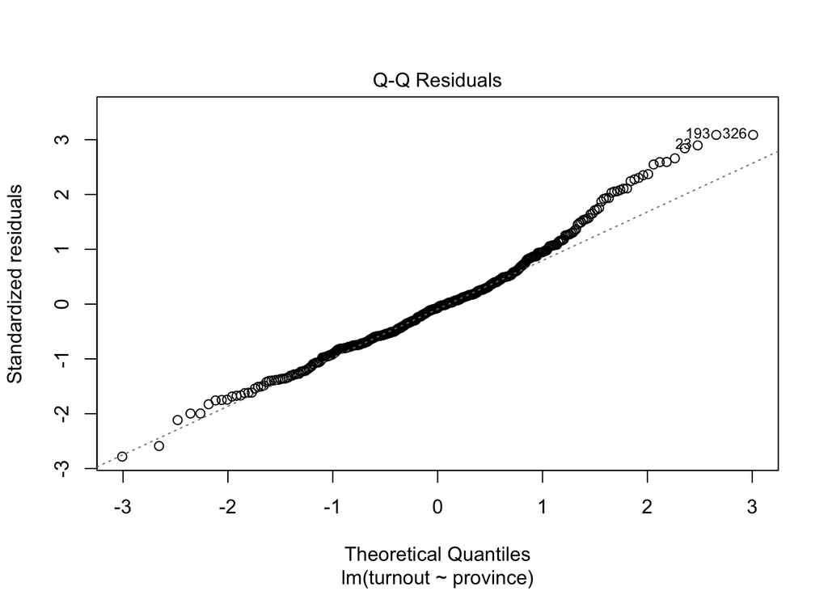

```r
lmod3 <- lm(turnout ~ province, data = q3data)
plot(lmod3, 2)
```

```r
anova(lmod3)
```

|  | Df | Sum Sq | Mean Sq | F value | Pr(>F) |
| --- | --- | --- | --- | --- | --- |
| province | 15 | 3354.592 | 223.63945 | 14.37488 | 8.686333e-29 |
| Residuals | 364 | 5662.986 | 15.55765 | NA | NA |

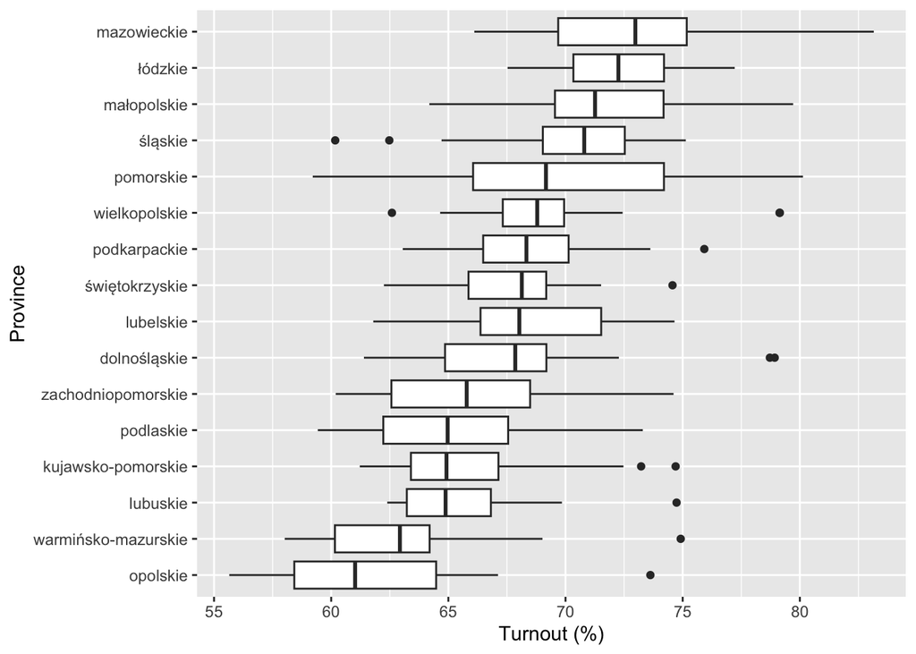

```r
ggplot(q3data, aes(x = reorder(province, turnout, FUN = median), y = turnout)) +
  geom_boxplot() +
  coord_flip() +
  xlab("Province") +
  ylab("Turnout (%)")
```

The F-test conclusion is supported by the boxplot, which shows a mixed spread of province turnouts and a high degree of within-province variability, especially for Mazowieckie and Pomorskie. Opolskie and Warmińsko-Mazurskie clearly separate at the lower end while the remaining provinces form a more gradual rise in turnout. At the upper end, no province appears exceptionally high or distinct from the general trend. Mazowieckie has the highest turnout percentage, a likely ranking given it contains Warsaw, the county with the highest official turnout seen in the dataset.

## 4. Spoilt Ballots

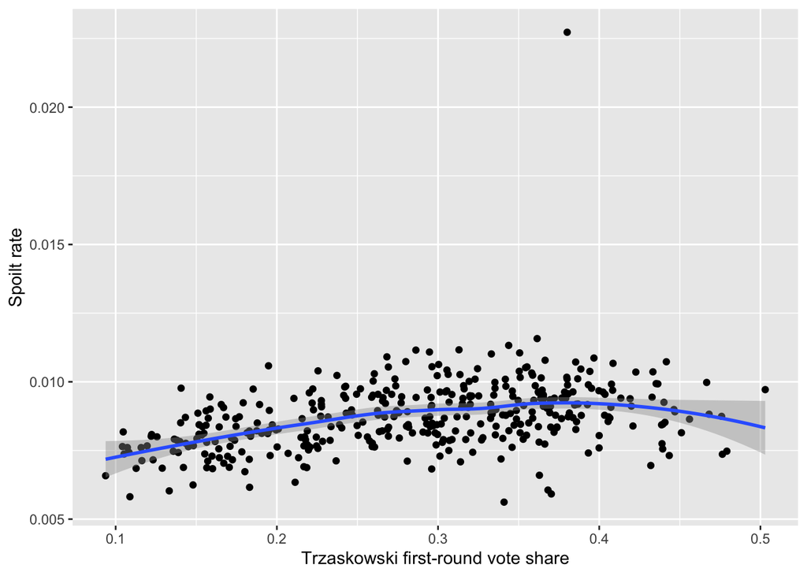

```r
q4data <- polpres
q4data$round1 <- rowSums(q4data[, candidates])
q4data$round2 <- q4data$N2 + q4data$T2 + q4data$spoilt
q4data$T_share <- q4data$Trzaskowski / q4data$round1
q4data$spoilt_rate <- q4data$spoilt / q4data$round2

ggplot(q4data, aes(T_share, spoilt_rate)) + geom_point() +
  geom_smooth() +
  xlab("Trzaskowski first-round vote share") + ylab("Spoilt rate")
```

```r
lmod4 <- lm(spoilt_rate ~ T_share, data = q4data)
summary(lmod4)
```

```
Call:
lm(formula = spoilt_rate ~ T_share, data = q4data)

Residuals:
       Min         1Q     Median         3Q        Max
-0.0033959 -0.0006795 -0.0000627  0.0006061  0.0135107

Coefficients:
             Estimate Std. Error t value Pr(>|t|)
(Intercept) 0.0072592  0.0002019   35.95  < 2e-16 ***
T_share     0.0051495  0.0006696    7.69 1.27e-13 ***
---
Signif. codes:  0 '***' 0.001 '**' 0.01 '*' 0.05 '.' 0.1 ' ' 1

Residual standard error: 0.00121 on 380 degrees of freedom
Multiple R-squared:  0.1347,    Adjusted R-squared:  0.1324
F-statistic: 59.14 on 1 and 380 DF,  p-value: 1.274e-13
```

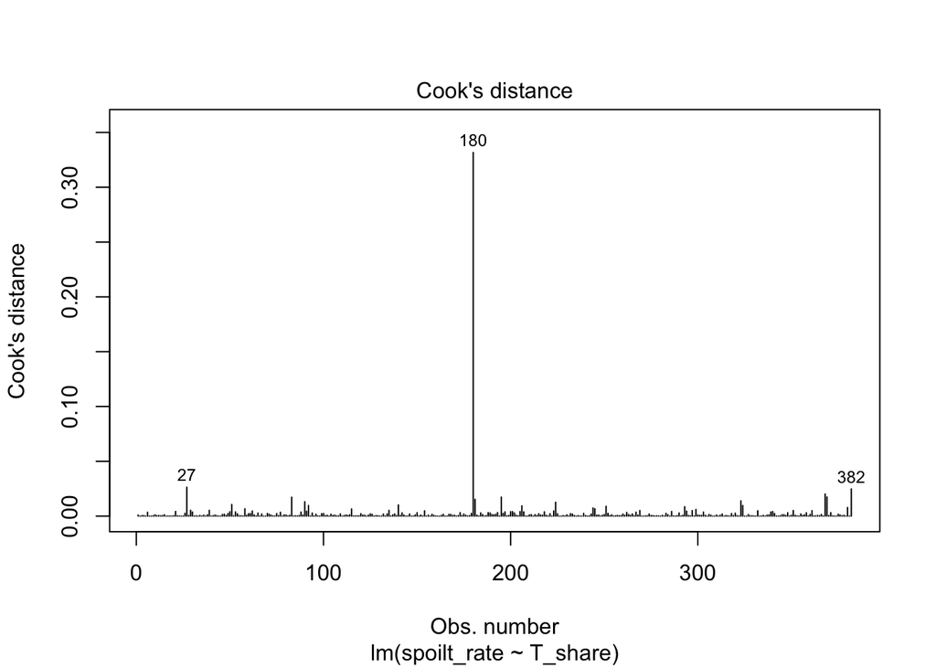

```r
plot(lmod4, 4)
```

Spoilt rate was modelled against Trzaskowski’s first-round vote share. Despite the clear high point in the scatter plot, no outlier values were removed as Cook’s distance was examined and no observations exceeded the conventional 0.5 threshold. The model summary shows a statistically significant positive coefficient (0.005, p < 0.01), suggesting counties with stronger first-round Trzaskowski support tend to have slightly higher spoilt rates. However, the relationship is weak, as reflected by the low R² of 0.135 and the substantial scatter in the data. The fitted trend is shallow, and the smooth curve suggests only a modest increase rather than a strong linear pattern. This suggests spoilt ballots were somewhat more common in areas with centre-left support, though the strength of this association is limited and conclusions should be treated with caution.

```r
q4data$left_share <- (q4data$Biejat + q4data$Zandberg) / q4data$round1
q4data$right_share <- (q4data$Braun + q4data$Mentzen + q4data$Nawrocki) / q4data$round1
q4data$centre_share <- (q4data$Hołownia + q4data$Trzaskowski) / q4data$round1

cors <- cor(q4data[, c("left_share", "right_share", "centre_share")])
cors
```

```
             left_share right_share centre_share
left_share    1.0000000  -0.8545181    0.7776510
right_share  -0.8545181   1.0000000   -0.9905043
centre_share  0.7776510  -0.9905043    1.0000000
```

To investigate further, first-round vote shares were computed for left-wing (Biejat, Zandberg), right-wing (Braun, Mentzen, Nawrocki) and centre (Hołownia, Trzaskowski) blocs. The remaining minor candidates were excluded from the classification as they are difficult to classify politically. The correlation matrix shows near-perfect collinearity (right-centre: -0.99), so a combined model would produce unreliable coefficients. This is especially important given the interpretation-nature of this task.

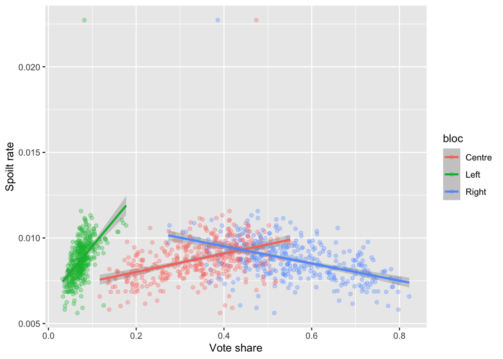

```r
q4data_long <- data.frame(
  spoilt_rate = rep(q4data$spoilt_rate, 3),
  share = c(q4data$left_share, q4data$right_share, q4data$centre_share),
  bloc = rep(c("Left", "Right", "Centre"), each = nrow(q4data))
)

ggplot(q4data_long, aes(share, spoilt_rate, color = bloc)) +
  geom_point(alpha = 0.3) +
  geom_smooth(method = "lm") +
  xlab("Vote share") + ylab("Spoilt rate")
```

The plot confirms a clear positive trend, consistent with the suggestion that spoilt ballot voters intended to vote for Trzaskowski. The broader political pattern is illustrated by overlaying fitted lines for left, right, and centre vote shares against spoilt rate. Left and centre shares show a positive association while right-wing share shows a negative one, though the opposing slopes for right and centre blocs are a direct consequence of their near-perfect negative correlation rather than independent evidence. This suggests spoilt ballot voters came from areas with centre-left political leanings, though as this is county-level data we cannot be certain about the intentions of individual voters, a clear example of the ecological fallacy.

## 5. USA-style election

```r
q5data <- polpres[!is.na(polpres$province) & polpres$province != "", ]

prov <- aggregate(cbind(T2, N2, eligible2) ~ province, data = q5data, FUN= sum)
prov$winner <- ifelse(prov$T2 > prov$N2, "Trzaskowski", "Nawrocki")
prov$ec_votes <- prov$eligible2
```

Given this question concerns provinces, Zagranica and statki were excluded as they are not true Polish counties and thus do not fall into any given province. For each province, we calculate the winning candidate who claims all electoral votes for that region. We represent each province’s electors by their number of eligible voters, mimicking the traditional, proportional representation assigned to states.

```r
prov$margin <- abs(prov$T2 - prov$N2)

ec_T <- sum(prov$ec_votes[prov$winner == "Trzaskowski"])
ec_N <- sum(prov$ec_votes[prov$winner == "Nawrocki"])
ec_winner <- ifelse(ec_T > ec_N, "Trzaskowski", "Nawrocki")

ec_winner_provs <- prov[prov$winner == ec_winner, ]
ec_winner_provs <- ec_winner_provs[order(ec_winner_provs$margin), ]

ec_lead <- abs(ec_T - ec_N)
best <- Inf
best_combo <- NULL
for (k in 1:nrow(ec_winner_provs)) {
  combos <- combn(1:nrow(ec_winner_provs), k, simplify = FALSE)
  for (combo in combos) {
    ec_swing <- sum(ec_winner_provs$ec_votes[combo]) * 2
    if (ec_swing > ec_lead) {
      cost <- sum(floor(ec_winner_provs$margin[combo] / 2) + 1)
      if (cost < best) {
        best <- cost
        best_combo <- combo
      }
    }
  }
}
```

Under the electoral college system, Trzaskowski wins, a direct reversal of the actual result. This highlights the influence of electoral systems and how their mechanisms can bring about vastly different outcomes when it comes to determining presidency.

```r
national_T <- sum(polpres$T2)
national_N <- sum(polpres$N2)
national_margin <- abs(national_T - national_N)
national_flips <- floor(national_margin / 2) + 1
```

## 6. Transfer of first round votes

```r
q6data <- polpres
q6data$round1 <- rowSums(q6data[, candidates])
q6data$round2 <- q6data$N2 + q6data$T2 + q6data$spoilt
q6data$others <- q6data$Bartoszewicz + q6data$Jakubiak + q6data$Maciak + q6data$Senyszyn + q6data$Stanowski + q6data$Woch
q6data$latejoins <- q6data$round2 - q6data$round1

lmod6 <- lm(T2 ~ Trzaskowski + Nawrocki + Biejat + Zandberg + Hołownia + Braun + Mentzen + others + latejoins - 1, data = q6data)
```

Every second-round voter either supported a first-round candidate or joined late, so the predictors account for all round 2 voters. The intercept is removed since zero first-round voters should produce zero second-round votes. To account for the stability of the finalists’ voter bases, their first-round totals were included as baseline controls. This allows the model to better isolate how the losing candidates’ voters redistributed their support.

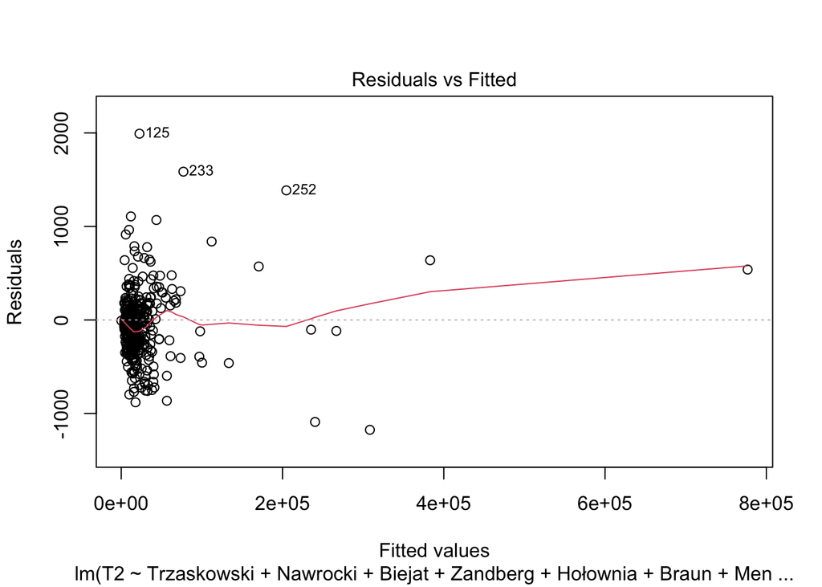

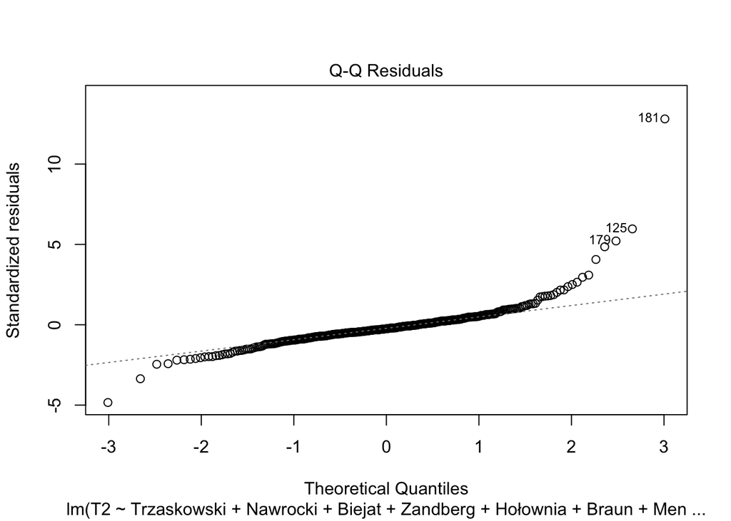

```r
plot(lmod6, c(1,2))
```

Diagnostic plots were checked. The residual-fitted plot shows variance increasing with fitted values, which is expected for count data where larger counties produce larger residuals. The Q-Q plot shows heavy tails with observation 181 particularly extreme. Refitting the model without this observation changed the magnitude of some coefficients but the overall pattern of transfers remained the same, so it was retained. Since the goal is to interpret coefficients as transfer proportions, a transformation of the response would not be appropriate as the coefficients would no longer have this interpretation. The increasing variance may affect standard error reliability, but this does not affect coefficient interpretation.

```r
coefs <- round(coef(lmod6), 3)
transfer <- data.frame(
  Group = c("Biejat", "Zandberg", "Hołownia", "Braun", "Mentzen", "Late joiners"),
  Trzaskowski = coefs[c("Biejat","Zandberg","Hołownia","Braun","Mentzen","latejoins")],
  Nawrocki = round(1 - coefs[c("Biejat","Zandberg","Hołownia","Braun","Mentzen","latejoins")], 3)
)
transfer
```

|  | Group | Trzaskowski | Nawrocki |
| --- | --- | --- | --- |
| Biejat | Biejat | 0.862 | 0.138 |
| Zandberg | Zandberg | 1.045 | -0.045 |
| Hołownia | Hołownia | 0.633 | 0.367 |
| Braun | Braun | 0.279 | 0.721 |
| Mentzen | Mentzen | 0.176 | 0.824 |
| latejoins | Late joiners | 0.753 | 0.247 |

Each coefficient estimates the proportion of that group transferring to Trzaskowski, with approximately (1 − coefficient) going to Nawrocki. As spoilt ballots are a small fraction of the round 2 total votes, they are absorbed into these proportions and have little effect on the overall conclusions.

This is an ecological regression, with individual transfer behaviour inferred from aggregate county-level data. The linear model does not constrain coefficients to [0, 1], and the predictors sum to round 2 totals for each county, introducing near-collinearity. These model constraints cause the Trzaskowski, Nawrocki, and Zandberg coefficients to fall outside [0, 1]. Trzaskowski and Nawrocki are control variables, not quantities of interest, and Zandberg’s value (1.045) is close enough to 1 to interpret as an approximately complete transfer. The four remaining eliminated candidates and late joiners remain interpretable.

The model estimates suggest left-wing voters transferred heavily to Trzaskowski, centrist voters leaned towards Trzaskowski, right-wing voters went predominantly to Nawrocki, and late joiners favoured Trzaskowski. These estimated transfers are consistent with political positioning.